# gun violence cross US

## data clean

from 1 January 2018 to 9 November 2021

```r
gun_violence_state_df=
read_csv("data/gun violence/mass shootings(all years).csv") %>%
  janitor::clean_names() %>%
  select(-incident_id,-address,-operations) %>%
  separate(incident_date,into=c("day","month","year"),sep="-") %>%
  group_by(state,year) %>%
  mutate(number_year_killed=sum(number_killed),number_year_injured=sum(number_injured),year=as.numeric(year)) %>%
  ungroup() %>%
  filter(year!="17") %>%
  mutate(year=year+2000)
```

## total number of mass shooting from 2018 - 2020 in America

nationally mass shootings jumped nearly 50% during a pandemic with crippling unemployment, violent protests and idle youth.

```r
year_massshooting=
    gun_violence_state_df %>%
    group_by(year) %>%
    mutate(number_mass_shooting=n()) %>%
    group_by(year,number_mass_shooting) %>%
    summarise() ## result is the same as shown in the table of website of GVA(gun violence archive)
```

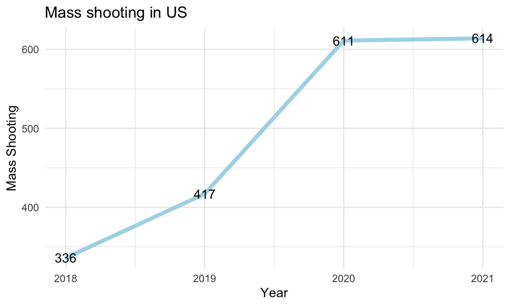

```r
year_massshooting %>%
  ggplot(aes(x=year,y=number_mass_shooting)) + geom_line(color="lightblue",size=1.6)+ geom_text(aes(label = number_mass_shooting)) + labs(x="Year",y="Mass Shooting",title= "Mass shooting in US")
```

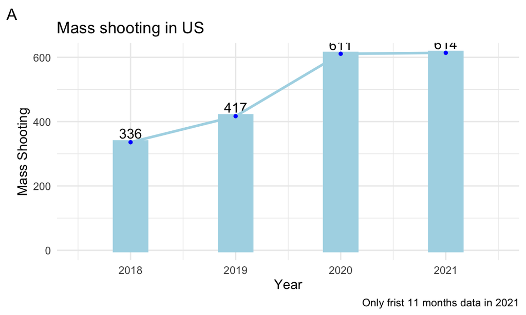

```r
year_massshooting %>%
  ggplot(aes(year,number_mass_shooting)) + geom_col(color="lightblue",size=1.6,fill="lightblue",position = "stack",width=0.3,size=6) + geom_text(aes(label = number_mass_shooting),size=4,position=position_dodge(1),vjust=-0.4,angle = 0) + labs(x="Year",y="Mass Shooting",title= "Mass shooting in US",caption = "Only frist 11 months data in 2021",colour = "Cylinders",tag = "A") +geom_line(size=1,color="lightblue") + geom_point(color="blue",size=1)
```

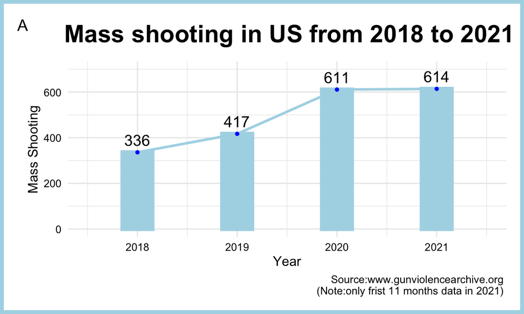

```r
year_massshooting %>%
  ggplot(aes(year,number_mass_shooting)) + geom_col(color="lightblue",size=1.6,fill="lightblue",position = "stack",width=0.3,size=6) + geom_text(aes(label = number_mass_shooting),size=4.5,position=position_dodge(1),vjust=-0.6,angle = 0) + labs(x="Year",y="Mass Shooting",title= "Mass shooting in US from 2018 to 2021",caption ="Source:www.gunviolencearchive.org \n (Note:only frist 11 months data in 2021) ",colour = "Cylinders",tag = "A") +geom_line(size=1,color="lightblue") + geom_point(color="blue",size=1) + theme(plot.background = element_rect(colour = "lightblue", size = 3, linetype = 1,
    fill = "white"), plot.title = element_text(colour = "black", face = "bold",
    size = 20, vjust = 2.5, hjust = 0.3), plot.margin = unit(c(0.2, 0.2, 0.2, 0.2), "inches"),axis.text=element_text(colour="black")) + scale_y_continuous(limits = c(0, 700))
```

## mass shooting in US

March 11 — WHO Declares COVID-19 a Pandemic

May 28 — US COVID-19 Deaths Pass the 100,000 Mark

June 10 — US COVID-19 Cases Reach 2 Million

January 20, 2020 CDC confirms the first U.S. laboratory-confirmed case of COVID-19 in the U.S. from samples taken on January 18 in Washington state

```r
year_month_state_massshooting=
  gun_violence_state_df %>%
  group_by(year,month,state) %>%
  mutate(number_mass_shooting=n()) %>%
  group_by(year,month,state,number_mass_shooting) %>%
  summarise() %>%
  mutate(year_month=str_c(year,month,sep="")) %>%
  mutate(month=match(month,month.abb)) %>%
  group_by(year) %>%
  arrange(month) %>%
  filter(year_month!="2021Nov")
```

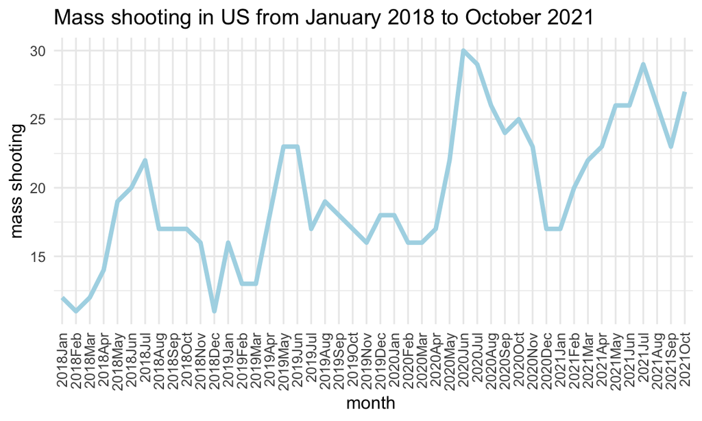

```r
year_month_state_massshooting %>%
  mutate(year_month=fct_inorder(year_month)) %>%
  group_by(year_month) %>%
  count() %>%
  rename(number_mass_shooting=n) %>%
  ggplot(aes(year_month,number_mass_shooting)) + geom_line(aes(group=1),color="lightblue",size=1.3) +
  theme(axis.text.x = element_text(angle = 90, vjust = 0.5, hjust =1)) + labs(x = "month ", y = "mass shooting", title = "Mass shooting in US from January 2018 to October 2021")
```

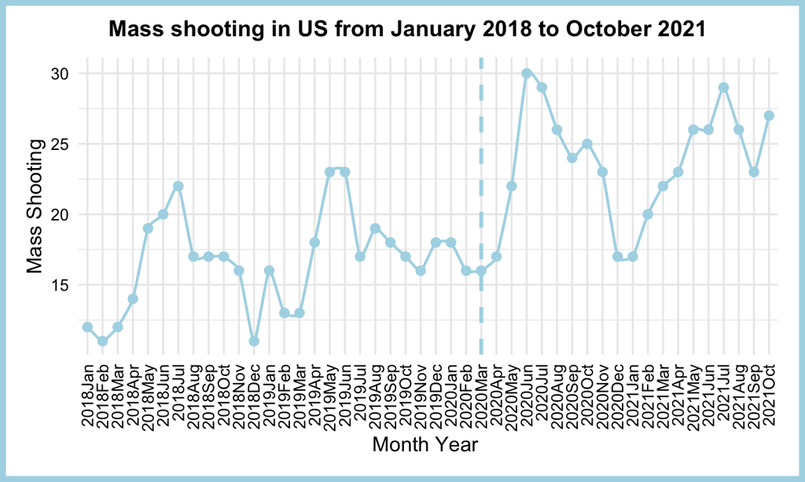

```r
year_month_state_massshooting %>%
  mutate(year_month=fct_inorder(year_month)) %>%
  group_by(year_month) %>%
  count() %>%
  rename(number_mass_shooting=n) %>%
  ggplot(aes(year_month,number_mass_shooting))  + geom_xspline(aes(group=1),color="lightblue",size=0.7) + geom_point(color="lightblue",size=2) +
  theme(axis.text.x = element_text(angle = 90, vjust = 0.5, hjust =1)) + labs(x = "Month Year ", y = "Mass Shooting", title = "Mass shooting in US from January 2018 to October 2021") + geom_vline(xintercept = 27 ,color= "lightblue",size=1,.5,linetype=8) + theme(plot.background = element_rect(colour = "lightblue", size = 3, linetype = 1,
    fill = "white"), plot.title = element_text(colour = "black", face = "bold",
    size = 12, vjust = 2.5, hjust = 0.3), plot.margin = unit(c(0.2, 0.2, 0.2, 0.2), "inches"),axis.text=element_text(colour="black"))
```

[figure not shown]

```r
year_month_state_massshooting %>%
  mutate(year_month=fct_inorder(year_month)) %>%
  group_by(year_month) %>%
  count() %>%
  rename(number_mass_shooting=n) %>%
  ggplot(aes(year_month,number_mass_shooting))  + geom_xspline(aes(group=1),color="lightblue",size=0.7) + geom_point(color="lightblue",size=2) +

  geom_segment(aes(x = 25, y = 10, xend = 25, yend = 32) ,colour = "lightblue",linetype="dashed") +
  geom_text(aes(x=25, y= 30, label = "first case of death in US " ), colour = "red", vjust = -2, hjust = 0.5, size = 2.5)  +


  labs(x = "Month Year ", y = "Mass Shooting", title = "Mass shooting in US from January 2018 to October 2021",caption="Source:www.gunviolencearchive.org",tag="B") + theme(plot.background = element_rect(colour = "lightblue", size = 3, linetype = 1,
    fill = "white"), plot.title = element_text(colour = "black", face = "bold",
    size = 12, vjust = 2.5, hjust = 0.3), plot.margin = unit(c(0.2, 0.2, 0.2, 0.2), "inches"),axis.text=element_text(colour="black")) + theme(axis.text.x = element_text(angle = 90, vjust = 0.5, hjust =1))
```

## according to states,arrange total number of mass shooting from 2018 to 2021 in 48 states in an ascending way

## bar plot

```r
mass_shooting_state=
  gun_violence_state_df %>%
  group_by(state) %>%
  count() %>%
  select(number_mass_shooting=n) %>%
  arrange(number_mass_shooting)
```

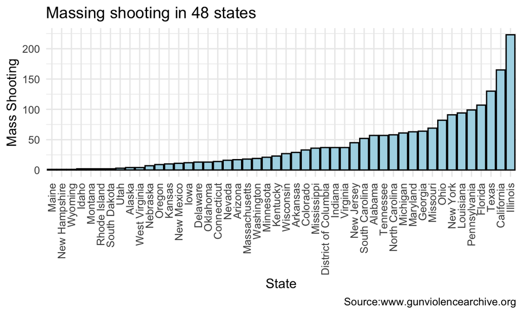

```r
mass_shooting_state %>%
  ggplot(aes(x=fct_reorder(state,number_mass_shooting),y=number_mass_shooting)) + geom_bar(stat = "identity", fill = "lightblue", colour = "black",position = "dodge") +
  theme(axis.text.x = element_text(angle = 90, vjust = 0.5, hjust =1))+ labs(y= "Mass Shooting", x = "State",title="Massing shooting in 48 states",caption="Source:www.gunviolencearchive.org")
```

```r
## write.csv(year_month_state_massshooting,"data/year_month_state_massshooting.csv")

year_state_massshooting=
  gun_violence_state_df %>%
    group_by(year,state) %>%
    mutate(number_mass_shooting=n()) %>%
    group_by(year,state,number_mass_shooting) %>%
    summarise()
```

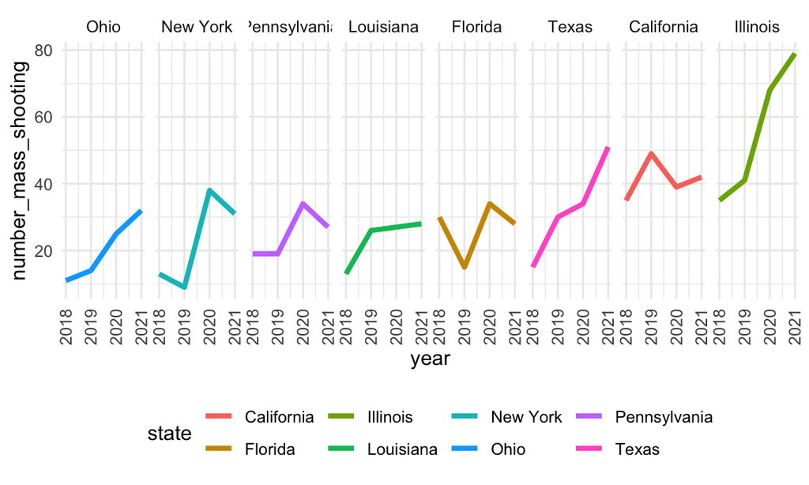

```r
year_state_massshooting %>%
  filter(state%in%c("Illinois","California","Texas","Florida","Pennsylvania","Louisiana","New York","Ohio")) %>%
  ggplot(aes(x=year,y=number_mass_shooting,color=state)) + geom_line(size=1.3) +  facet_grid(~fct_reorder(state,number_mass_shooting))+theme(axis.text.x = element_text(angle = 90, vjust = 0.5, hjust =1))
```

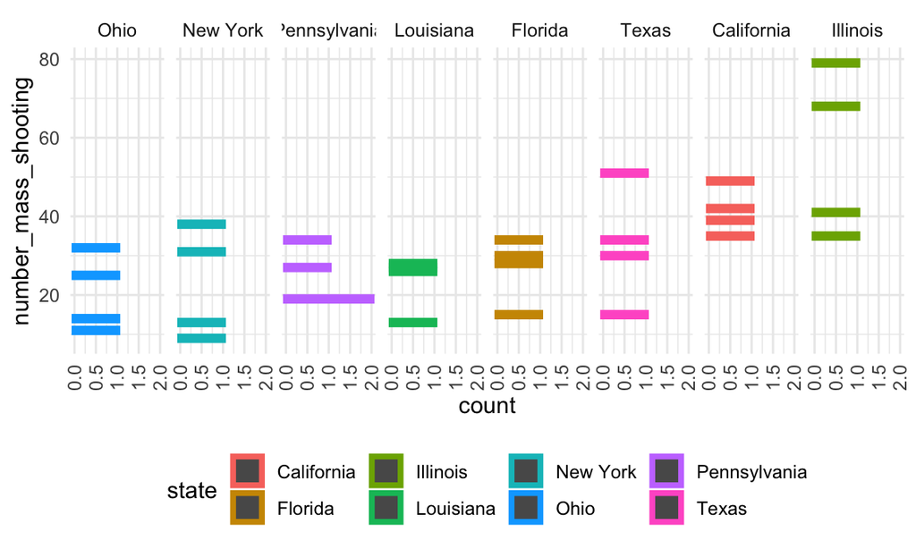

```r
year_state_massshooting %>%
  filter(state%in%c("Illinois","California","Texas","Florida","Pennsylvania","Louisiana","New York","Ohio")) %>%
  group_by(year) %>%
  ggplot(aes(y=number_mass_shooting,color=state)) + geom_bar(size=1.3) +  facet_grid(~fct_reorder(state,number_mass_shooting))+theme(axis.text.x = element_text(angle = 90, vjust = 0.5, hjust =1))
```

[figure not shown]

```r
gun_violence_state_df %>%

  ggplot(aes(state)) + geom_bar()
```

## number of people killed and injured in mass shooting from Juanary 2018 to 2021 (since 2021 has not ended,so the latest date is 2021.11.9)

```r
gun_violence_state_df %>%
  group_by(year) %>%
  mutate(year_nation_killed=sum(number_year_killed),year_nation_injured=sum(number_year_injured)) %>%
  group_by(year,year_nation_killed,year_nation_injured) %>%
  summarise()
```

```
## # A tibble: 4 × 3
## # Groups:   year, year_nation_killed [4]
##    year year_nation_killed year_nation_injured
##   <dbl>              <dbl>               <dbl>
## 1  2018               6844               23451
## 2  2019              10153               36520
## 3  2020              12930               70426
## 4  2021              17186               80303
```

[figure not shown]

```r
plot_usmap(include = c("NY")) +
  labs(title = "Western US States",
       subtitle = "These are the states in the Pacific Timezone.")
```